# AE 01 - UN Votes

Spencer Robbins

2026-02-21

## Introduction

How do various countries vote in the United Nations General Assembly, how have their voting patterns evolved throughout time, and how similarly or differently do they view certain issues? Answering these questions (at a high level) is the focus of this analysis.

**In this application exercise, you will:**

- Practice the fork-then-clone workflow
- Load and explore data from an R package
- Join multiple datasets together
- Create visualizations with ggplot2
- Use `group_by()` and `summarize()` to calculate percentages
- Interpret trends over time

**Estimated time:** 30-45 minutes

## Getting Started

### Fork and Clone Workflow

**IMPORTANT:** Application exercises use the same fork-then-clone workflow as labs. Here’s how to get started:

#### Step 1: Fork the Repository

1. Go to the course application exercises repository on GitHub: `[CourseOrg]/application-exercises`
2. Click the **Fork** button in the top-right corner
3. This creates YOUR OWN copy: `YourUsername/application-exercises`
4. You now have full permissions to push to your fork

**Why fork?** - Creates your personal copy under your GitHub account - Gives you permission to push your work - Keeps your work separate from other students - Allows instructors to see your individual progress

#### Step 2: Clone Your Fork to JupyterHub

1. In JupyterHub, open RStudio
2. Click **File → New Project → Version Control → Git**
3. **Repository URL:** Paste the URL of **YOUR forked repository**
   - Your fork: `https://github.com/YourUsername/application-exercises` ✅
   - NOT the course repo: `https://github.com/CourseOrg/application-exercises` ❌
4. **Project directory name:** Leave as `application-exercises`
5. **Create project as subdirectory of:** Choose where you want it (default is fine)
6. Click **Create Project**

#### Step 3: Verify Your Setup

**Check that you’re in YOUR fork:** - Look at the **Git pane** in RStudio - The remote should show: `YourUsername/application-exercises` - If it shows the course organization name, you cloned the wrong repository!

**If you cloned the course repository by mistake:** - Delete the project folder - Start over with Step 1 (Fork first!)

#### Step 4: Navigate to This Exercise

1. In RStudio’s **Files** pane, navigate to the `ae-01-un-votes` folder
2. Open `ae-01-un-votes.Rmd`
3. Update the YAML with your name
4. Click **Knit** to make sure it works

#### Step 5: Commit and Push

After completing the exercise (or periodically as you work):

1. Click the **Git** pane
2. Check the boxes next to changed files
3. Click **Commit**
4. Write a message (e.g., “Completed UN Votes exercise”)
5. Click **Commit** then **Push**
6. Verify your work appears in **YOUR fork** on GitHub

**Remember:** You’re pushing to `YourUsername/application-exercises`, NOT the course repository!

## Packages

We will use the **tidyverse**, **lubridate**, and **scales** packages for data wrangling and visualization, the **DT** package for interactive display of tabular output, and the **unvotes** package for the data.

```r
library(tidyverse)
library(lubridate)
library(scales)
library(DT)
library(unvotes)
```

**What these packages do:** - **tidyverse:** Data wrangling (dplyr) and visualization (ggplot2) - **lubridate:** Working with dates and times - **scales:** Formatting axis labels (like percentages) - **DT:** Creating interactive tables - **unvotes:** Contains UN voting data

## Data

The data we’re using originally come from the **unvotes** package. In the chunk below we modify the data by joining the various data frames provided in the package to help you get started with the analysis.

```r
unvotes <- un_votes %>%
  inner_join(un_roll_calls, by = "rcid") %>%
  inner_join(un_roll_call_issues, by = "rcid") %>%
  mutate(date = as.Date(date))  # Convert to proper Date format
```

**What this code does:** - `un_votes`: Contains how each country voted on each resolution - `un_roll_calls`: Contains information about each resolution (date, description) - `un_roll_call_issues`: Contains the issue category for each resolution - `inner_join()`: Combines these datasets based on the resolution ID (`rcid`) - `mutate(date = as.Date(date))`: Converts date to proper Date format - Result: One dataset with votes, dates, and issue categories

**Explore the data:**

```r
# View the structure
glimpse(unvotes)
```

```
## Rows: 857,878
## Columns: 14
## $ rcid          <dbl> 6, 6, 6, 6, 6, 6, 6, 6, 6, 6, 6, 6, 6, 6, 6, 6, 6, 6, 6,…
## $ country       <chr> "United States", "Canada", "Cuba", "Dominican Republic",…
## $ country_code  <chr> "US", "CA", "CU", "DO", "MX", "GT", "HN", "SV", "NI", "P…
## $ vote          <fct> no, no, yes, abstain, yes, no, yes, abstain, yes, abstai…
## $ session       <dbl> 1, 1, 1, 1, 1, 1, 1, 1, 1, 1, 1, 1, 1, 1, 1, 1, 1, 1, 1,…
## $ importantvote <int> 0, 0, 0, 0, 0, 0, 0, 0, 0, 0, 0, 0, 0, 0, 0, 0, 0, 0, 0,…
## $ date          <date> 1946-01-04, 1946-01-04, 1946-01-04, 1946-01-04, 1946-01…
## $ unres         <chr> "R/1/107", "R/1/107", "R/1/107", "R/1/107", "R/1/107", "…
## $ amend         <int> 0, 0, 0, 0, 0, 0, 0, 0, 0, 0, 0, 0, 0, 0, 0, 0, 0, 0, 0,…
## $ para          <int> 0, 0, 0, 0, 0, 0, 0, 0, 0, 0, 0, 0, 0, 0, 0, 0, 0, 0, 0,…
## $ short         <chr> "DECLARATION OF HUMAN RIGHTS", "DECLARATION OF HUMAN RIG…
## $ descr         <chr> "TO ADOPT A CUBAN PROPOSAL (A/3-C) THAT AN ITEM ON A DEC…
## $ short_name    <chr> "hr", "hr", "hr", "hr", "hr", "hr", "hr", "hr", "hr", "h…
## $ issue         <fct> Human rights, Human rights, Human rights, Human rights, …
```

```r
# See the first few rows
head(unvotes)
```

```
## # A tibble: 6 × 14
##    rcid country  country_code vote  session importantvote date       unres amend
##   <dbl> <chr>    <chr>        <fct>   <dbl>         <int> <date>     <chr> <int>
## 1     6 United … US           no          1             0 1946-01-04 R/1/…     0
## 2     6 Canada   CA           no          1             0 1946-01-04 R/1/…     0
## 3     6 Cuba     CU           yes         1             0 1946-01-04 R/1/…     0
## 4     6 Dominic… DO           abst…       1             0 1946-01-04 R/1/…     0
## 5     6 Mexico   MX           yes         1             0 1946-01-04 R/1/…     0
## 6     6 Guatema… GT           no          1             0 1946-01-04 R/1/…     0
## # ℹ 5 more variables: para <int>, short <chr>, descr <chr>, short_name <chr>,
## #   issue <fct>
```

**Key variables:** - `country`: Name of the country - `vote`: How they voted (yes, no, abstain) - `date`: Date of the vote - `issue`: Category of the resolution (e.g., Human rights, Colonialism)

## Exercise 1: Explore the Data

Before creating visualizations, let’s explore the data to understand what we’re working with.

**Task 1.1:** How many unique countries are in the dataset?

```r
# Count unique countries
unvotes %>%
  distinct(country) %>%
  nrow()
```

```
## [1] 200
```

**Answer:** There are 200 countries in the data set.

**Task 1.2:** What are the unique vote options?

```r
# See unique values of vote
unvotes %>%
  distinct(vote)
```

```
## # A tibble: 3 × 1
##   vote
##   <fct>
## 1 no
## 2 yes
## 3 abstain
```

**Answer:** The vote options are: NO, Yes, and Abstain.

**Task 1.3:** What issue categories are included?

```r
# See unique issues
unvotes %>%
  distinct(issue)
```

```
## # A tibble: 6 × 1
##   issue
##   <fct>
## 1 Human rights
## 2 Economic development
## 3 Colonialism
## 4 Palestinian conflict
## 5 Arms control and disarmament
## 6 Nuclear weapons and nuclear material
```

**Answer:** The issue categories are: -Human rights -Economic development -Colonialism -Palestinian conflict -Arms control and disarmament -Nuclear weapons and nuclear material.

## UN Voting Patterns

Now let’s create a data visualization that displays how the voting record of the UK & NI changed over time on a variety of issues, and compares it to two other countries: US and Turkey.

### Understanding the Code

Let’s break down what the code below does, step by step:

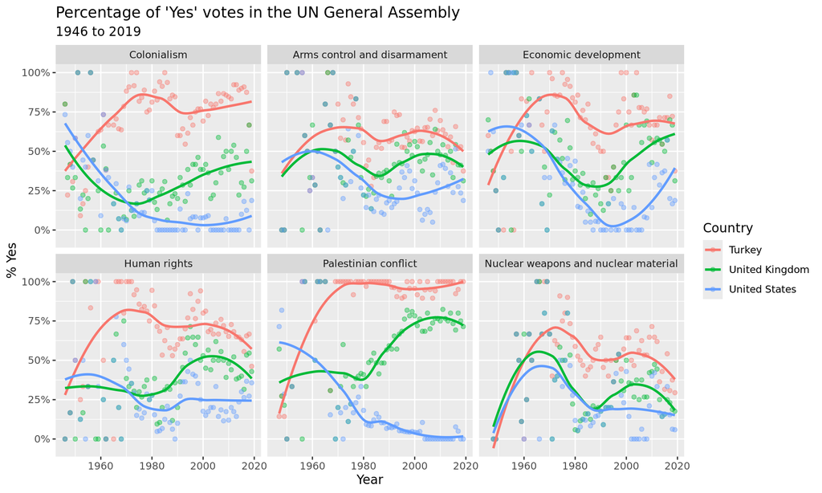

```r
unvotes %>%
  # Step 1: Filter for specific countries
  filter(country %in% c("United Kingdom", "United States", "Turkey")) %>%

  # Step 2: Extract the year from the date
  mutate(year = year(date)) %>%

  # Step 3: Group by country, year, and issue
  group_by(country, year, issue) %>%

  # Step 4: Calculate percentage of "yes" votes
  summarize(percent_yes = mean(vote == "yes")) %>%

  # Step 5: Create the plot
  ggplot(mapping = aes(x = year, y = percent_yes, color = country)) +
  geom_point(alpha = 0.4) +
  geom_smooth(method = "loess", se = FALSE) +
  facet_wrap(~issue) +
  scale_y_continuous(labels = percent) +
  labs(
    title = "Percentage of 'Yes' votes in the UN General Assembly",
    subtitle = "1946 to 2019",
    y = "% Yes",
    x = "Year",
    color = "Country"
  )
```

**Code explanation:**

1. **filter():** Keeps only rows for UK, US, and Turkey
2. **mutate():** Creates a new `year` variable by extracting the year from the `date`
3. **group_by():** Groups data by country, year, and issue
4. **summarize():** For each group, calculates the percentage of “yes” votes
   - `mean(vote == "yes")` works because TRUE = 1 and FALSE = 0
5. **ggplot():** Creates a scatterplot with smoothed trend lines
   - `geom_point()`: Adds points
   - `geom_smooth()`: Adds trend lines
   - `facet_wrap()`: Creates separate panels for each issue
   - `scale_y_continuous()`: Formats y-axis as percentages

## Exercise 2: Interpret the Visualization

**Task 2.1:** Describe the overall trend for the United Kingdom on Human Rights issues.

**Your answer:**

The human rights for the united kingdom back in 1960 was around 30% and it dipped to 25% around 1980. Latter at 2000 it jumps to 50% then starts to decrease to about 40% in 2020.

**Task 2.2:** Which country appears most consistent in its voting patterns across all issues? Which appears least consistent?

**Your answer:**

The country that appears the most consistent is the united kingdom across all issues, while the united state appears the least consistent across all issues.

**Task 2.3:** On which issue do the three countries show the most similar voting patterns? On which issue do they differ the most?

**Your answer:**

Most similar:

The most similar is nuclear weapons and nuclear material, because all three lines are close together on the chart.

Most different:

The most different is Palestinian conflict, because all three are on different parts of the graph as speperate as possible.

## Exercise 3: Modify the Countries

We can easily change which countries are being plotted by changing which countries the code `filter`s for.

**Note:** The country name should be spelled and capitalized exactly the same way as it appears in the data. See the Appendix for a list of the countries in the data.

**Task 3.1:** Modify the code to compare three different countries of your choice.

```r
# Copy the code from above and modify the filter() line
unvotes %>%
  filter(country %in% c("Canada", "Japan", "Germany")) %>%  # Change these!
  mutate(year = year(date)) %>%
  group_by(country, year, issue) %>%
  summarize(percent_yes = mean(vote == "yes")) %>%
  ggplot(mapping = aes(x = year, y = percent_yes, color = country)) +
  geom_point(alpha = 0.4) +
  geom_smooth(method = "loess", se = FALSE) +
  facet_wrap(~issue) +
  scale_y_continuous(labels = percent) +
  labs(
    title = "Percentage of 'Yes' votes in the UN General Assembly",
    subtitle = "1946 to 2019",
    y = "% Yes",
    x = "Year",
    color = "Country"
  )
```

[output not shown]

**Which countries did you choose?** Canada, Japan, and Germany

**Task 3.2:** Describe one interesting pattern you notice in your new plot.

**Your answer:**

These three countries are very similar for almost all of the voting patterns. Also Germany doesn’t show up in the voting until about 1990.

## Exercise 4: Focus on One Issue

**Task 4.1:** Create a plot that shows voting patterns for ONLY the “Human rights” issue, but includes more countries.

**Hint:** You’ll need to add a `filter()` step for the issue, and modify the countries in the first `filter()`.

```r
unvotes %>%
  filter(country %in% c("Canada", "Japan", "Germany", "China", "Russia")) %>%  # Choose 5 countries
  filter(issue == "Human rights") %>%  # Filter for Human rights
  mutate(year = year(date)) %>%
  group_by(country, year) %>%
  summarize(percent_yes = mean(vote == "yes")) %>%
  ggplot(mapping = aes(x = year, y = percent_yes, color = country)) +
  geom_point(alpha = 0.4) +
  geom_smooth(method = "loess", se = FALSE) +
  scale_y_continuous(labels = percent) +
  labs(
    title = "Percentage of 'Yes' votes in the UN General Assembly",  # Update title
    subtitle = "1946 to 2019",
    y = "% Yes",
    x = "Year",
    color = "Country"
  )
```

[output not shown]

**Describe what you see:**

For the five countries the lowest yes votes for human rights in 2020 was Canada, while the highest was China. In 1980 Canada and Japan were about 30% while China and Russia was about 85% yes votes.

## Exercise 5: Calculate Summary Statistics

**Task 5.1:** Calculate the overall percentage of “yes” votes for each country across all issues and all years.

```r
country_yes_percent <- unvotes %>%
  group_by(country) %>%
  summarize(
    total_votes = n(),
    percent_yes = mean(vote == "yes") * 100
  ) %>%
  arrange(desc(percent_yes))

# View the top 10
head(country_yes_percent, 10)
```

[output not shown]

**Which country has the highest overall percentage of “yes” votes?**

Seychelles is the overall highest percentage of yes votes.

**Which has the lowest?**

Maldives is the overall lowest percentage of yes votes.

**Task 5.2:** Calculate the percentage of “yes” votes by issue, averaged across all countries and all years.

```r
issue_yes_percent <- unvotes %>%
  group_by(issue) %>%
  summarize(
    percent_yes = mean(vote == "yes") * 100
  ) %>%
  arrange(desc(percent_yes))

issue_yes_percent
```

[output not shown]

**Which issue has the most “yes” votes on average?**

Palestinian conflict has the most yes votes on average.

**Which has the least?**

Human rights has the least yes votes on average.

## Exercise 6: Challenge (Optional)

**Task 6.1:** Create a visualization that shows how voting similarity between the US and other countries has changed over time for one specific issue.

**Hints:** - You’ll need to calculate agreement (both voted yes, or both voted no) - You might want to focus on a few specific countries - Consider using a line plot with `geom_line()`

```r
# Your code here (this is challenging - try your best!)
```

## Knit and Submit

**Before you finish:**

1. ✅ Make sure all code chunks run without errors
2. ✅ Fill in all answer spaces
3. ✅ Knit to HTML first (click **Knit** button)
4. ✅ Review the HTML output

**Git workflow:**

1. Click the **Git** pane
2. Check boxes next to all changed files
3. Click **Commit**
4. Write a commit message: “Completed AE 01 - UN Votes”
5. Click **Commit**
6. Click **Push**
7. Verify your work is on GitHub in **YOUR fork**

**Check GitHub:** - Go to `github.com/YourUsername/application-exercises` - Navigate to `ae-01-un-votes` folder - Verify you see your updated `.Rmd` file - You should also see the rendered `.html` file

## Generate PDF for Canvas Submission

Once you’ve verified everything works and committed your changes to GitHub:

### Step 1: Knit to PDF

1. Click the **Knit** dropdown arrow (next to the Knit button)
2. Select **Knit to PDF**
3. Wait for the PDF to generate (this may take a minute)

**Troubleshooting PDF generation:**

- **Error: “LaTeX not found”**
  - Install tinytex in R Console: `tinytex::install_tinytex()`
  - Restart RStudio after installation
  - Try knitting to PDF again
- **Plot doesn’t fit on page**
  - Adjust `fig.width` and `fig.height` in chunk options
  - Or add to YAML: `geometry: margin=1in`
- **Country table (Appendix) causing issues**
  - The interactive `datatable()` might not render well in PDF
  - This is okay - the PDF is mainly for your answers

### Step 2: Locate Your PDF

After successful PDF generation:

1. Look in the **Files** pane (bottom-right)
2. Find `ae-01-un-votes.pdf` in your `ae-01-un-votes` folder
3. Click the checkbox next to the PDF file
4. Click **More → Export…**
5. Save the PDF to your computer

### Step 3: Submit to Canvas

1. Go to Canvas
2. Navigate to the AE 01 assignment
3. Upload `ae-01-un-votes.pdf`
4. Submit

**Note:** You submit the PDF to Canvas AND push your work to GitHub. Both are required!

## References

1. David Robinson (2017). unvotes: United Nations General Assembly Voting Data. R package version 0.2.0.
2. Erik Voeten “Data and Analyses of Voting in the UN General Assembly” Routledge Handbook of International Organization, edited by Bob Reinalda (published May 27, 2013).
3. Much of the analysis has been modeled on the examples presented in the [unvotes package vignette](https://cran.r-project.org/web/packages/unvotes/vignettes/unvotes.html).

## Appendix

Below is a list of countries in the dataset:

|  | country |
| --- | --- |
| 1 | Afghanistan |
| 2 | Albania |
| 3 | Algeria |
| 4 | Andorra |
| 5 | Angola |
| 6 | Antigua &amp; Barbuda |
| 7 | Argentina |
| 8 | Armenia |
| 9 | Australia |
| 10 | Austria |

[output cut: 190 more lines]

## Troubleshooting

**Common issues:**

- **“Permission denied” when pushing:** You cloned the course repo instead of your fork. Delete the project and start over with forking first!
- **Error: “could not find function”:** Make sure you ran the package loading chunk
- **Plot doesn’t show up:** Make sure you ran all the code chunks in order
- **Country name not found:** Check the Appendix for exact spelling and capitalization

**PDF-specific issues:**

- **“LaTeX not found” or “pdflatex not found”**
  - Install tinytex: Run `tinytex::install_tinytex()` in R Console
  - Restart RStudio
  - Try knitting to PDF again
- **PDF generation fails**
  - Try knitting to HTML first to make sure code works
  - Check that all plots have reasonable `fig.width` and `fig.height`
  - The interactive table in the Appendix may not render in PDF (that’s okay)
- **PDF looks different from HTML**
  - This is normal - PDFs have different formatting
  - Focus on making sure your answers and plots are clear
- **Can’t find the PDF file**
  - Look in the same folder as your .Rmd file
  - It should be named `ae-01-un-votes.pdf`
  - Use the Files pane in RStudio to locate it

**If you’re stuck:**

- Review the walkthrough video
- Check the course discussion board
- Ask during office hours